# The importance of controlling for block effects and the use of paired t-tests

Dan McGlinn

2024-03-25

In complex systems such as a forest it is rare that the variable you are interested is only influenced by a single other variable. In fact, the driver variable that you are testing the effect of may be obscured because of variation due to a different variable.

For example, you might be interested in comparing the effect of nutrient addition on plant growth but you know that plant growth is also strongly driven by salinity. If we wish to apply our inference about nutrients across a salinity gradient then we should replicate our nutrient addition at different salinities. Since we are not necessarily interested in the salinity effect we are treating it more as a nuisance variable or a “block” effect.

Let’s examine the incorrect approach to this analysis using a linear model that ignores the block effect, and then we will examine how the model interpretation changes once the block effect is correctly considered. We will see that controlling for the block effect is the same as using a paired (aka 1 sample) t-test.

```r
set.seed(1)
```

First setup the block variable

```r
nblock <- 20
block <- rep(1:nblock, each = 2)
block
```

```
##  [1]  1  1  2  2  3  3  4  4  5  5  6  6  7  7  8  8  9  9 10 10 11 11 12 12 13
## [26] 13 14 14 15 15 16 16 17 17 18 18 19 19 20 20
```

Treatment will just have two levels: 0 = control, 1 = treatment

```r
trt <- rep(0:1, nblock)
trt
```

```
##  [1] 0 1 0 1 0 1 0 1 0 1 0 1 0 1 0 1 0 1 0 1 0 1 0 1 0 1 0 1 0 1 0 1 0 1 0 1 0 1
## [39] 0 1
```

set error or uncertainty of model

```r
noise <- 0.1
err <- rnorm(length(trt), mean = 0, sd = noise)
```

Now we can generate response variable y using a linear model where we know the coefficients. Note the last term with Gaussian noise is added in.

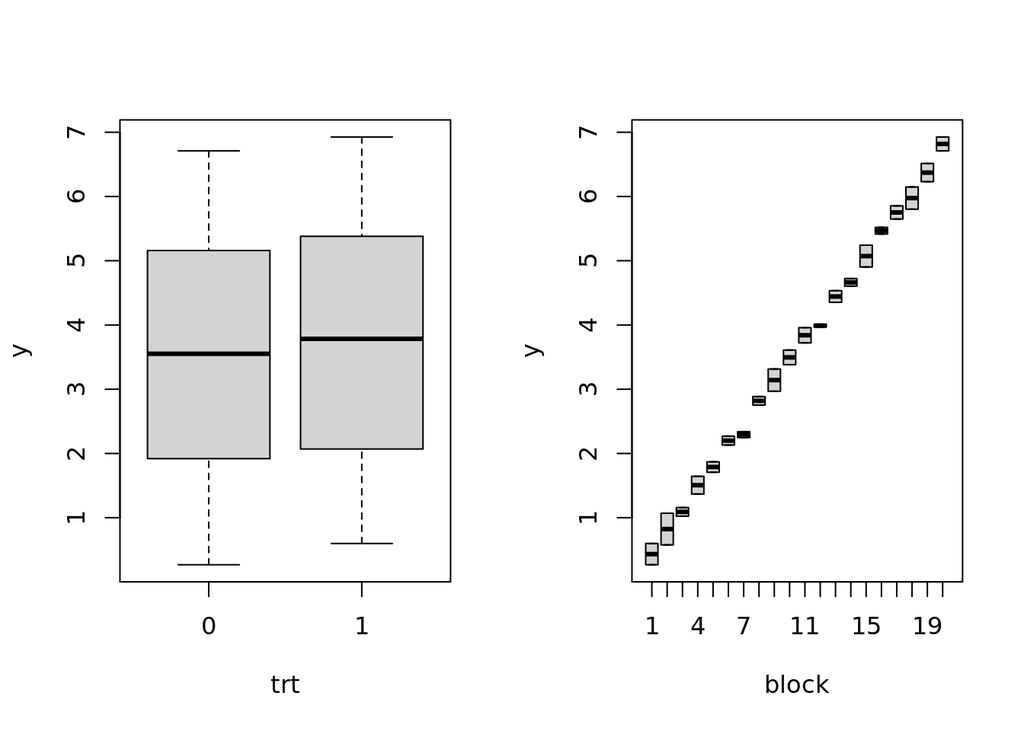

```r
y <- 0.33 * block + 0.25 * trt + err

par(mfrow=c(1,2))
boxplot(y ~ trt)
boxplot(y ~ block)
```

note above that the figures show that most of the variation in `y` is due to block effects rather than treatment effects. These strong block effects have the potential to obsurce treatment effects if they are ignored.

```r
# recode block and treatment as factors
block <- as.factor(block)
trt <- as.factor(trt)
```

Let’s fit models. We will find that if block is ignored then treatment has no effect similar to ignoring important biology you get wrong answer (i.e., not signifianct). Note tje `trt` coefficient is still correct (i.e., matches what we set in our model) which is impressive.

```r
summary(lm(y ~ trt))
```

```
##
## Call:
## lm(formula = y ~ trt)
##
## Residuals:
##     Min      1Q  Median      3Q     Max
## -3.2217 -1.5257  0.0664  1.6019  3.2210
##
## Coefficients:
##             Estimate Std. Error t value Pr(>|t|)
## (Intercept)   3.4890     0.4361   8.000 1.14e-09 ***
## trt1          0.2203     0.6168   0.357    0.723
## ---
## Signif. codes:  0 '***' 0.001 '**' 0.01 '*' 0.05 '.' 0.1 ' ' 1
##
## Residual standard error: 1.951 on 38 degrees of freedom
## Multiple R-squared:  0.003347,   Adjusted R-squared:  -0.02288
## F-statistic: 0.1276 on 1 and 38 DF,  p-value: 0.7229
```

if you include block with treatment in the model now you get correct inference (i.e., trt p-value < 0.05)

```r
summary(lm(y ~ block + trt))
```

```
##
## Call:
## lm(formula = y ~ block + trt)
##
## Residuals:
##      Min       1Q   Median       3Q      Max
## -0.13637 -0.04292  0.00000  0.04292  0.13637
##
## Coefficients:
##             Estimate Std. Error t value Pr(>|t|)
## (Intercept)  0.32268    0.05741   5.620 2.03e-05 ***
## block2       0.39012    0.07924   4.923 9.43e-05 ***
## block3       0.65759    0.07924   8.299 9.68e-08 ***
## block4       1.07343    0.07924  13.547 3.26e-11 ***
## block5       1.35566    0.07924  17.109 5.33e-13 ***
## block6       1.76722    0.07924  22.303 4.35e-15 ***
## block7       1.86034    0.07924  23.478 1.70e-15 ***
## block8       2.38614    0.07924  30.114  < 2e-16 ***
## block9       2.70852    0.07924  34.182  < 2e-16 ***
## block10      3.06290    0.07924  38.655  < 2e-16 ***
## block11      3.40720    0.07924  43.000  < 2e-16 ***
## block12      3.55640    0.07924  44.883  < 2e-16 ***
## block13      4.01033    0.07924  50.612  < 2e-16 ***
## block14      4.23081    0.07924  53.394  < 2e-16 ***
## block15      4.63913    0.07924  58.547  < 2e-16 ***
## block16      5.03494    0.07924  63.543  < 2e-16 ***
## block17      5.31883    0.07924  67.126  < 2e-16 ***
## block18      5.54254    0.07924  69.949  < 2e-16 ***
## block19      5.93946    0.07924  74.958  < 2e-16 ***
## block20      6.38530    0.07924  80.585  < 2e-16 ***
## trt1         0.22035    0.02506   8.794 4.00e-08 ***
## ---
## Signif. codes:  0 '***' 0.001 '**' 0.01 '*' 0.05 '.' 0.1 ' ' 1
##
## Residual standard error: 0.07924 on 19 degrees of freedom
## Multiple R-squared:  0.9992, Adjusted R-squared:  0.9983
## F-statistic:  1154 on 20 and 19 DF,  p-value: < 2.2e-16
```

now let’s consider that each sample in each block is a paired sample. In other words we are most interested in the comparison of the samples within the blocks not between the blocks

To carry out paired test we need to compute the differences in y in the two treatment levels. This is easiest if we reshape the data to wide format

```r
dat <- data.frame(y, block, trt)
dat_pair <- tidyr::pivot_wider(dat, names_from = trt,
                              names_prefix = 'trt_',
                              values_from = y)
head(dat_pair)
```

```
## # A tibble: 6 × 3
##   block trt_0 trt_1
##   <fct> <dbl> <dbl>
## 1 1     0.267 0.598
## 2 2     0.576 1.07
## 3 3     1.02  1.16
## 4 4     1.37  1.64
## 5 5     1.71  1.87
## 6 6     2.13  2.27
```

now we can compute diff directly for testing

```r
dat_pair$diff <- dat_pair$trt_1 - dat_pair$trt_0
```

we can use the `t.test` function with the formula response ~ 1 here the 1 indicates that this is a paired 1 sample test. Usually the 1 is the grouping variable

```r
t.test(dat_pair$diff ~ 1)
```

```
##
##  One Sample t-test
##
## data:  dat_pair$diff
## t = 8.7939, df = 19, p-value = 3.998e-08
## alternative hypothesis: true mean is not equal to 0
## 95 percent confidence interval:
##  0.1679045 0.2727942
## sample estimates:
## mean of x
## 0.2203494
```

Rather than compute the difference manually in trt_1 and trt_0 we can use the `Pair` function

```r
t.test(Pair(trt_1, trt_0) ~ 1, data = dat_pair)
```

```
##
##  Paired t-test
##
## data:  Pair(trt_1, trt_0)
## t = 8.7939, df = 19, p-value = 3.998e-08
## alternative hypothesis: true mean difference is not equal to 0
## 95 percent confidence interval:
##  0.1679045 0.2727942
## sample estimates:
## mean difference
##       0.2203494
```

Ok let’s see if the paired t-test gave us a different result to our simple linear model

```r
summary(lm(y ~ block + trt))
```

```
##
## Call:
## lm(formula = y ~ block + trt)
##
## Residuals:
##      Min       1Q   Median       3Q      Max
## -0.13637 -0.04292  0.00000  0.04292  0.13637
##
## Coefficients:
##             Estimate Std. Error t value Pr(>|t|)
## (Intercept)  0.32268    0.05741   5.620 2.03e-05 ***
## block2       0.39012    0.07924   4.923 9.43e-05 ***
## block3       0.65759    0.07924   8.299 9.68e-08 ***
## block4       1.07343    0.07924  13.547 3.26e-11 ***
## block5       1.35566    0.07924  17.109 5.33e-13 ***
## block6       1.76722    0.07924  22.303 4.35e-15 ***
## block7       1.86034    0.07924  23.478 1.70e-15 ***
## block8       2.38614    0.07924  30.114  < 2e-16 ***
## block9       2.70852    0.07924  34.182  < 2e-16 ***
## block10      3.06290    0.07924  38.655  < 2e-16 ***
## block11      3.40720    0.07924  43.000  < 2e-16 ***
## block12      3.55640    0.07924  44.883  < 2e-16 ***
## block13      4.01033    0.07924  50.612  < 2e-16 ***
## block14      4.23081    0.07924  53.394  < 2e-16 ***
## block15      4.63913    0.07924  58.547  < 2e-16 ***
## block16      5.03494    0.07924  63.543  < 2e-16 ***
## block17      5.31883    0.07924  67.126  < 2e-16 ***
## block18      5.54254    0.07924  69.949  < 2e-16 ***
## block19      5.93946    0.07924  74.958  < 2e-16 ***
## block20      6.38530    0.07924  80.585  < 2e-16 ***
## trt1         0.22035    0.02506   8.794 4.00e-08 ***
## ---
## Signif. codes:  0 '***' 0.001 '**' 0.01 '*' 0.05 '.' 0.1 ' ' 1
##
## Residual standard error: 0.07924 on 19 degrees of freedom
## Multiple R-squared:  0.9992, Adjusted R-squared:  0.9983
## F-statistic:  1154 on 20 and 19 DF,  p-value: < 2.2e-16
```

the coefficient estimate and t values of `trt` is identical between the paired t-test and the linear model which includes block as a factor. In this special case if we want to summary the test results using ANOVA we can use the default `anova` function which carries out sequential tests (i.e., the order of the variables in the models matters!). Here we want to first factor out block effects then test `trt` effect

```r
anova(lm(y ~ block + trt))
```

```
## Analysis of Variance Table
##
## Response: y
##           Df  Sum Sq Mean Sq  F value    Pr(>F)
## block     19 144.451  7.6027 1210.906 < 2.2e-16 ***
## trt        1   0.486  0.4855   77.333 3.998e-08 ***
## Residuals 19   0.119  0.0063
## ---
## Signif. codes:  0 '***' 0.001 '**' 0.01 '*' 0.05 '.' 0.1 ' ' 1
```

we can verify that this is identical to the more usual type 3 anova test we are typically interesed when using observational (rather than experimental) datasets.

```r
car::Anova(lm(y ~ block + trt), type = 3)
```

```
## Anova Table (Type III tests)
##
## Response: y
##              Sum Sq Df  F value    Pr(>F)
## (Intercept)   0.198  1   31.589 2.028e-05 ***
## block       144.451 19 1210.906 < 2.2e-16 ***
## trt           0.486  1   77.333 3.998e-08 ***
## Residuals     0.119 19
## ---
## Signif. codes:  0 '***' 0.001 '**' 0.01 '*' 0.05 '.' 0.1 ' ' 1
```